# (13) Intro to timeseries analysis

Lasse Ruokolainen, Bilot Consulting Oy

# 1 Timeseries visualization

## 1.1 *autoplot*

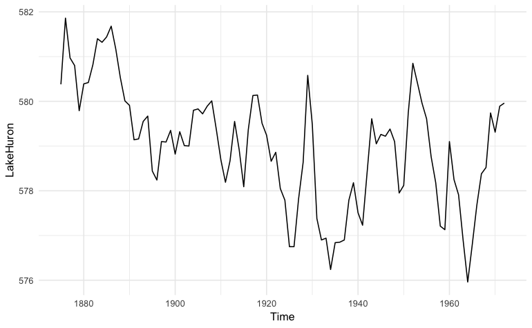

```r
library(forecast)

# Load time series data:
data(LakeHuron)

autoplot(LakeHuron) +
  theme_minimal()
```

## 1.2 *Autocorrelation*

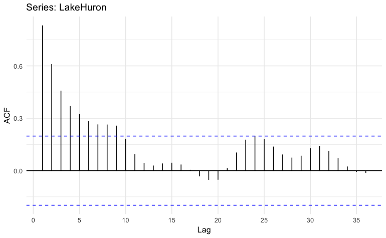

```r
ggAcf(x = LakeHuron, lag.max = 36) +
  theme_minimal()
```

# 2 Seasonality

As an example, we can use the `ldeaths` data, giving the monthly deaths from bronchitis, emphysema and asthma in the UK, 1974–1979. The data looks like this:

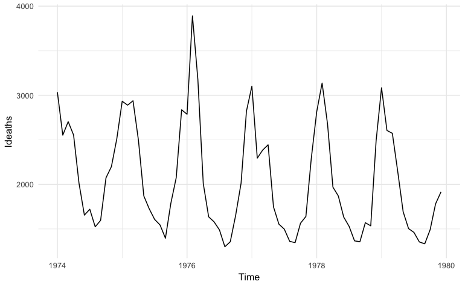

```r
autoplot(ldeaths) +
  theme_minimal()
```

## 2.1 *Seasonal decomposition*

The time series is clearly periodic. We can extract the seasonality, possible long-term trend, and any remaining variation using the `stl()` function:

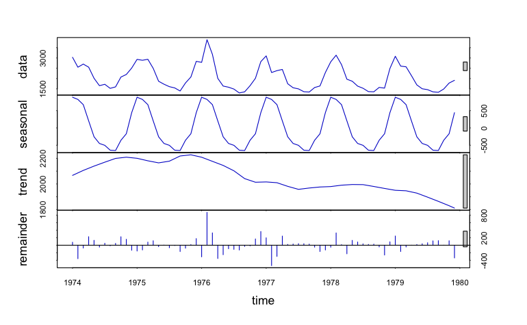

```r
# make decomposition:
decomp = stl(ldeaths,'periodic')

# Visualize:
plot(decomp,col='blue3')
```

## 2.2 *Detrending*

The resulting decomposition can be used to *detrend* the original time series:

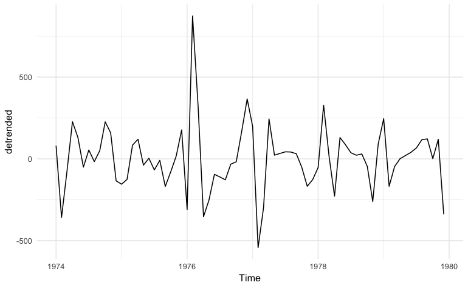

```r
detrended = ldeaths - decomp$time.series[,1] -
  decomp$time.series[,2]
autoplot(detrended) +
  theme_minimal()
```